# More Logistic regression

Fundamental Techniques in Data Science with R

## Packages Used

```r
library(magrittr) # pipes
library(dplyr)    # data manipulation
library(mice)     # data
library(lattice)  # plotting - used for conditional plotting
library(ggplot2)  # plotting
library(DAAG)     # data sets and functions
library(caret)    # confusion matrices
```

## Recap

With **logistic regression** we can model a binary outcome using a set of continuous and/or categorical predictors.

- If we use **linear regression** to model a binary outcome variable, we would create a *linear probability model*.

The linear probability model is a (bad) way to describe the conditional probabilities.

- The residual variance is not constant (violation of homoscedasticity)
- The residuals are not normally distributed

Because the linear probability model violates some assumptions of the linear model, the standard errors and hypothesis tests are not valid.

- In short, you may draw invalid conclusions.

## Titanic data

## Example: Titanic Data

We will begin this lecture with a data set that records the survival of the passengers on the maiden voyage of the Titanic.

```r
titanic <- read.csv(file = "titanic.csv", header = TRUE, stringsAsFactors = TRUE)
titanic %>% head()
```

```
##   Survived Pclass                                               Name    Sex Age
## 1        0      3                             Mr. Owen Harris Braund   male  22
## 2        1      1 Mrs. John Bradley (Florence Briggs Thayer) Cumings female  38
## 3        1      3                              Miss. Laina Heikkinen female  26
## 4        1      1        Mrs. Jacques Heath (Lily May Peel) Futrelle female  35
## 5        0      3                            Mr. William Henry Allen   male  35
## 6        0      3                                    Mr. James Moran   male  27
##   Siblings.Spouses.Aboard Parents.Children.Aboard    Fare
## 1                       1                       0  7.2500
## 2                       1                       0 71.2833
## 3                       0                       0  7.9250
## 4                       1                       0 53.1000
## 5                       0                       0  8.0500
## 6                       0                       0  8.4583
```

## Inspect the Data

```r
str(titanic)
```

```
## 'data.frame':    887 obs. of  8 variables:
##  $ Survived               : int  0 1 1 1 0 0 0 0 1 1 ...
##  $ Pclass                 : int  3 1 3 1 3 3 1 3 3 2 ...
##  $ Name                   : Factor w/ 887 levels "Capt. Edward Gifford Crosby",..: 602 823 172 814 733 464 700 33 842 839 ...
##  $ Sex                    : Factor w/ 2 levels "female","male": 2 1 1 1 2 2 2 2 1 1 ...
##  $ Age                    : num  22 38 26 35 35 27 54 2 27 14 ...
##  $ Siblings.Spouses.Aboard: int  1 1 0 1 0 0 0 3 0 1 ...
##  $ Parents.Children.Aboard: int  0 0 0 0 0 0 0 1 2 0 ...
##  $ Fare                   : num  7.25 71.28 7.92 53.1 8.05 ...
```

## Available Variables

The outcome/dependent variable:

- *Survived*: yes or no

Some potential predictors:

- *Sex*: The passenger’s sex coded as {male, female}
- *Pclass*: The class of the passenger’s ticket
- *Age*: The passenger’s age in years
- *Siblings.Spouses.Aboard*: Were the passenger’s sibling(s) or spouse aboard?
- *Parents.Children.Aboard*: Were the passenger’s parents or children aboard?

## Hypothetically

We can start investigating if there are patterns in this data that are related to the survival probability.

For example, we could hypothesize based on the crede “women and children first” that

- `Age` relates to the probability of survival in that younger passengers have a higher probability of survival
- `Sex` relates to survival in that females have a higher probability of survival

Based on socio-economic status, we could hypothesize that

- `Pclass` relates to the probability of survival in that higher travel class leads to a higher probability of survival

And so on.

## A quick investigation

## Is `Age` related?

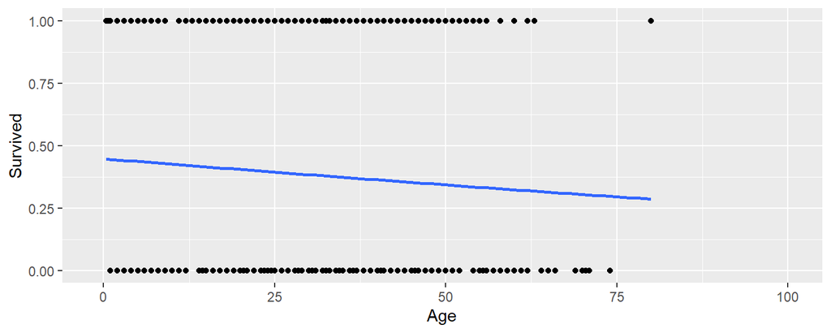

```r
titanic %>% ggplot(aes(x = Age, y = Survived)) + geom_point() +
  geom_smooth(method = "glm",
    method.args = list(family = "binomial"),
    se = FALSE) + xlim(-1, 100)
```

## Inspecting the data

```r
titanic %$% table(Pclass, Survived)
```

```
##       Survived
## Pclass   0   1
##      1  80 136
##      2  97  87
##      3 368 119
```

It seems that the higher the class (i.e. `1 > 2 > 3`), the higher the probability of survival.

We can verify this

```r
titanic %$% table(Pclass, Survived) %>% prop.table(margin = 1) %>% round(digits = 2)
```

```
##       Survived
## Pclass    0    1
##      1 0.37 0.63
##      2 0.53 0.47
##      3 0.76 0.24
```

## A more thorough inspection

## Fitting the titanic models

Let’s fit these models and gradually build them up in the number of predictors.

```r
fit1 <- titanic %$%
  glm(Survived ~ Age, family = binomial(link="logit"))

fit2 <- titanic %$%
  glm(Survived ~ Sex, family = binomial(link="logit"))

fit3 <- titanic %$%
  glm(Survived ~ Pclass, family = binomial(link="logit"))
```

## `Survived ~ Age`

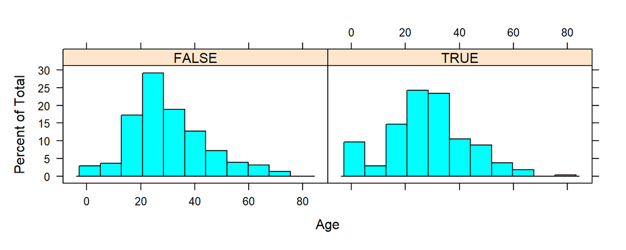

```r
titanic %$% histogram(~ Age | Survived == 1)
```

The distribution of `Age` for the survivors (`TRUE`) is different from the distribution of `Age` for the non-survivors (`FALSE`). Especially at the younger end there is a point mass for the survivors, which indicates that children have a higher probability of survival. However, it is not dramatically different.

## `Survived ~ Age`

```r
fit1 %>% summary %>% .$coefficients
```

```
##                 Estimate  Std. Error   z value   Pr(>|z|)
## (Intercept) -0.209188757 0.159493684 -1.311580 0.18966182
## Age         -0.008774355 0.004947362 -1.773542 0.07613892
```

We can see that there is a trend. The log odds of `Survived` decreases with increasing `Age`. For every year increase in age, the log-odds of `Survived` decreases with -0.0087744. However, this decrease is not too convincing given the effect, the standard error and the size of the data. Hence, the p-value is a little on the larger side.

When we inspect the deviance

```r
c(fit1$null.deviance, fit1$deviance)
```

```
## [1] 1182.770 1179.593
```

We see that there is almost no decrease in deviance between the empty model (i.e. the model with only an intercept) and the model with `Age` included. The difference in df is only 1 parameter.

## `Survived ~ Sex`

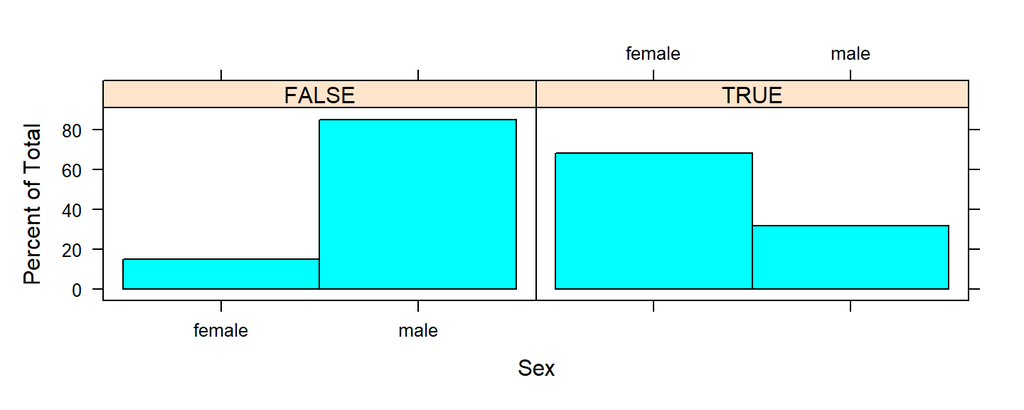

```r
titanic %$% histogram(~ Sex | Survived == 1)
```

Wow! These distributions are very different! Females seem to have a much higher probability of survival.

## `Survived ~ Sex`

```r
fit2 %>% summary %>% coef
```

```
##              Estimate Std. Error    z value     Pr(>|z|)
## (Intercept)  1.056589  0.1289864   8.191477 2.580394e-16
## Sexmale     -2.505126  0.1672333 -14.979827 9.947556e-51
```

The coefficients confirm this. The log odds of `Survived` decreases for males, when compared to females. The decrease is quite pronounced, too: -2.505126.

When we inspect the deviance

```r
c(fit2$null.deviance, fit2$deviance)
```

```
## [1] 1182.7699  916.1224
```

We see that there is a massive gain in the deviance between the empty model (i.e. the model with only an intercept - represented by `null.deviance`) and the model with `Sex` included. The difference in df is only 1 parameter.

## `Survived ~ Pclass`

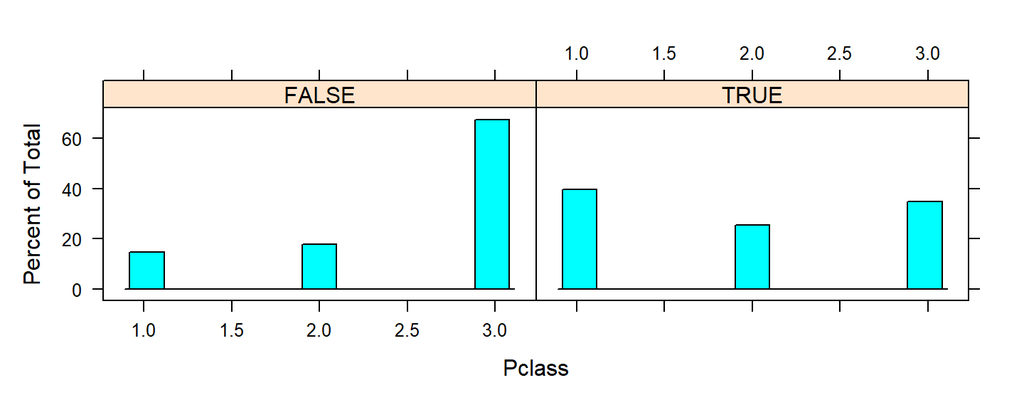

```r
titanic %$% histogram(~ Pclass | Survived == 1)
```

## `Survived ~ Pclass`

```r
fit3 %>% summary %>% coef
```

```
##               Estimate Std. Error   z value     Pr(>|z|)
## (Intercept)  1.4390660 0.20742485  6.937771 3.983356e-12
## Pclass      -0.8442286 0.08719006 -9.682624 3.574230e-22
```

Here, there is something wrong! Class is an ordered categorical variable, not a continuous variable. In other words, we cannot simply increase the log odds of `Survived` with -0.8442286 for every unit increase in `Pclass`.

### Why not?

If we would interpret these coefficients ‘as is’, we would assume that class two is twice the value for class 1, that class three is 1.5 times the value for class 2, and so on.

## Edit the data

```r
titanic %<>%
  mutate(Pclass = factor(Pclass, levels = c(3, 2, 1), ordered = FALSE))
str(titanic)
```

```
## 'data.frame':    887 obs. of  8 variables:
##  $ Survived               : int  0 1 1 1 0 0 0 0 1 1 ...
##  $ Pclass                 : Factor w/ 3 levels "3","2","1": 1 3 1 3 1 1 3 1 1 2 ...
##  $ Name                   : Factor w/ 887 levels "Capt. Edward Gifford Crosby",..: 602 823 172 814 733 464 700 33 842 839 ...
##  $ Sex                    : Factor w/ 2 levels "female","male": 2 1 1 1 2 2 2 2 1 1 ...
##  $ Age                    : num  22 38 26 35 35 27 54 2 27 14 ...
##  $ Siblings.Spouses.Aboard: int  1 1 0 1 0 0 0 3 0 1 ...
##  $ Parents.Children.Aboard: int  0 0 0 0 0 0 0 1 2 0 ...
##  $ Fare                   : num  7.25 71.28 7.92 53.1 8.05 ...
```

The `Pclass` column is now correctly coded as a factor. We ignore the ordering as this goes beyond the scope of the course.

## Titanic with main effects

```
##
## Call:
## glm(formula = Survived ~ Age + Sex + Pclass, family = binomial(link = "logit"))
##
## Deviance Residuals:
##     Min       1Q   Median       3Q      Max
## -2.6811  -0.6653  -0.4137   0.6367   2.4505
##
## Coefficients:
##             Estimate Std. Error z value Pr(>|z|)
## (Intercept)  1.17948    0.22784   5.177 2.26e-07 ***
## Age         -0.03427    0.00716  -4.787 1.69e-06 ***
## Sexmale     -2.58872    0.18701 -13.843  < 2e-16 ***
## Pclass2      1.25633    0.22646   5.548 2.90e-08 ***
## Pclass1      2.45544    0.25322   9.697  < 2e-16 ***
## ---
## Signif. codes:  0 '***' 0.001 '**' 0.01 '*' 0.05 '.' 0.1 ' ' 1
##
## (Dispersion parameter for binomial family taken to be 1)
##
##     Null deviance: 1182.77  on 886  degrees of freedom
## Residual deviance:  801.59  on 882  degrees of freedom
## AIC: 811.59
##
## Number of Fisher Scoring iterations: 5
```

## Titanic with interactions

```r
fit.interaction <- titanic %$% glm(Survived ~ Age * Sex * Pclass,
                                   family = binomial(link="logit"))
fit.interaction %>% summary %>% .$coefficients
```

```
##                        Estimate Std. Error    z value    Pr(>|z|)
## (Intercept)          0.38542858 0.35158572  1.0962578 0.272965982
## Age                 -0.01742787 0.01399943 -1.2448985 0.213169059
## Sexmale             -1.24102347 0.51966698 -2.3881130 0.016935134
## Pclass2              3.66379424 1.38138966  2.6522525 0.007995671
## Pclass1              1.11218683 1.49587117  0.7435044 0.457176346
## Age:Sexmale         -0.02261191 0.02066970 -1.0939639 0.273970802
## Age:Pclass2         -0.03196246 0.03845267 -0.8312158 0.405851754
## Age:Pclass1          0.08036169 0.05283156  1.5210925 0.128236622
## Sexmale:Pclass2     -1.91119761 1.57587112 -1.2127880 0.225210878
## Sexmale:Pclass1      0.81487712 1.66024791  0.4908165 0.623556217
## Age:Sexmale:Pclass2 -0.03128163 0.04938976 -0.6333627 0.526496788
## Age:Sexmale:Pclass1 -0.08001824 0.05687997 -1.4067912 0.159489308
```

## Interactions

An interaction occurs when the (causal) effect of one predictor on the outcome depends on the level of the (causal) effect of another predictor.

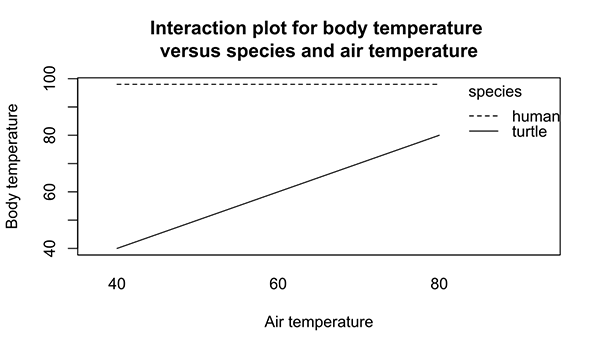

[Image Source](https://en.wikipedia.org/wiki/File:Interaction_plot_body_temp.svg)

E.g. the relation between body temperature and air temperature depends on the species.

## Visualizing the effects

To illustrate, I will limit this investigation to `Age` and `Pclass` for males only.

- We can use the `predict` function to illustrate the conditional probabilities within each class

To do so, we need to create a `new` data frame that has all the combinations of predictors we need.

```r
new <- data.frame(Pclass = factor(rep(c(1, 2, 3), c(80, 80, 80))),
                  Age = rep(1:80, times = 3),
                  Sex = rep("male", times = 240))
new <- cbind(new,
             predict(fit.interaction, newdata = new,
                     type = "link", se = TRUE))
head(new)
```

```
##   Pclass Age  Sex       fit    se.fit residual.scale
## 1      1   1 male 1.0317727 0.5963908              1
## 2      1   2 male 0.9920764 0.5826134              1
## 3      1   3 male 0.9523801 0.5688767              1
## 4      1   4 male 0.9126838 0.5551835              1
## 5      1   5 male 0.8729874 0.5415373              1
## 6      1   6 male 0.8332911 0.5279416              1
```

## Adding the predicted probabilities

There are two simple approaches to obtain the predicted probabilities. First, we could simply ask for the predicted response:

```r
new$prob <- predict(fit.interaction, newdata = new, type = "response")
```

Or we could use the distribution function `plogis()`:

```r
new$prob2 <- plogis(new$fit)
head(new)
```

```
##   Pclass Age  Sex       fit    se.fit residual.scale      prob     prob2
## 1      1   1 male 1.0317727 0.5963908              1 0.7372594 0.7372594
## 2      1   2 male 0.9920764 0.5826134              1 0.7294979 0.7294979
## 3      1   3 male 0.9523801 0.5688767              1 0.7215936 0.7215936
## 4      1   4 male 0.9126838 0.5551835              1 0.7135490 0.7135490
## 5      1   5 male 0.8729874 0.5415373              1 0.7053669 0.7053669
## 6      1   6 male 0.8332911 0.5279416              1 0.6970504 0.6970504
```

## Adding confidence intervals

```r
new %<>%
  mutate(lower = plogis(fit - 1.96 * se.fit),
         upper = plogis(fit + 1.96 * se.fit))

head(new)
```

```
##   Pclass Age  Sex       fit    se.fit residual.scale      prob     prob2
## 1      1   1 male 1.0317727 0.5963908              1 0.7372594 0.7372594
## 2      1   2 male 0.9920764 0.5826134              1 0.7294979 0.7294979
## 3      1   3 male 0.9523801 0.5688767              1 0.7215936 0.7215936
## 4      1   4 male 0.9126838 0.5551835              1 0.7135490 0.7135490
## 5      1   5 male 0.8729874 0.5415373              1 0.7053669 0.7053669
## 6      1   6 male 0.8332911 0.5279416              1 0.6970504 0.6970504
##       lower     upper
## 1 0.4657654 0.9003122
## 2 0.4626085 0.8941640
## 3 0.4594348 0.8876919
## 4 0.4562432 0.8808856
## 5 0.4530325 0.8737357
## 6 0.4498011 0.8662333
```

## What do we have?

A data frame with simulated `Pclass` and `Age` for males.

```r
new %>% summary()
```

```
##  Pclass      Age            Sex                 fit              se.fit
##  1:80   Min.   : 1.00   Length:240         Min.   :-7.3657   Min.   :0.1588
##  2:80   1st Qu.:20.75   Class :character   1st Qu.:-3.2680   1st Qu.:0.2879
##  3:80   Median :40.50   Mode  :character   Median :-1.7875   Median :0.4157
##         Mean   :40.50                      Mean   :-2.0998   Mean   :0.5133
##         3rd Qu.:60.25                      3rd Qu.:-0.7446   3rd Qu.:0.6093
##         Max.   :80.00                      Max.   : 1.0318   Max.   :1.6068
##  residual.scale      prob               prob2               lower
##  Min.   :1      Min.   :0.0006322   Min.   :0.0006322   Min.   :0.0000271
##  1st Qu.:1      1st Qu.:0.0366906   1st Qu.:0.0366906   1st Qu.:0.0118488
##  Median :1      Median :0.1433767   Median :0.1433767   Median :0.0826488
##  Mean   :1      Mean   :0.2129610   Mean   :0.2129610   Mean   :0.1360227
##  3rd Qu.:1      3rd Qu.:0.3220022   3rd Qu.:0.3220022   3rd Qu.:0.2223781
##  Max.   :1      Max.   :0.7372594   Max.   :0.7372594   Max.   :0.4657654
##      upper
##  Min.   :0.01454
##  1st Qu.:0.10794
##  Median :0.25041
##  Mean   :0.31211
##  3rd Qu.:0.44139
##  Max.   :0.90031
```

## Visualizing the effects: link

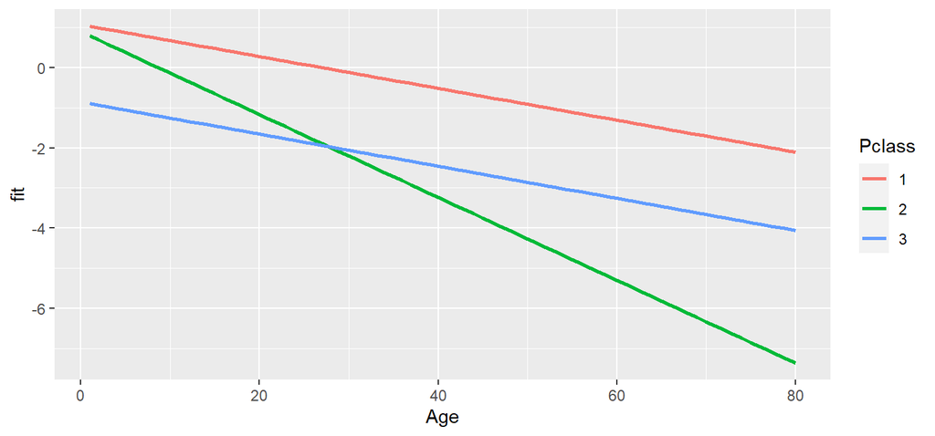

```r
new %>%
  ggplot(aes(x = Age, y = fit)) +
  geom_line(aes(colour = Pclass), lwd = 1)
```

## Visualizing the effects: probabilities

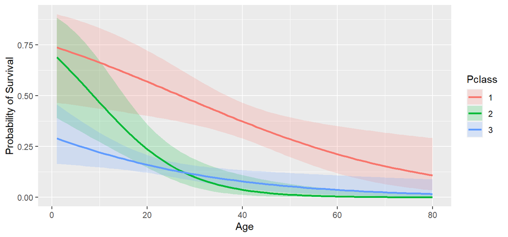

```r
new %>%
  ggplot(aes(x = Age, y = prob)) +
  geom_ribbon(aes(ymin = lower, ymax = upper, fill = Pclass), alpha = .2) +
  geom_line(aes(colour = Pclass), lwd = 1) + ylab("Probability of Survival")
```

## No interaction assumed

To repeat the previous scenario for the model where only main effects are included:

```r
fit <- titanic %$% glm(Survived ~ Age + Sex + Pclass, family = binomial(link="logit"))
new2 <- new %>% select(Age, Pclass, Sex)
new2 <- cbind(new2, predict(fit, newdata = new2, type = "link", se = TRUE))
new2 %<>%
  mutate(prob = plogis(fit),
         lower = plogis(fit - 1.96 * se.fit),
         upper = plogis(fit + 1.96 * se.fit))
```

## No interaction: the link

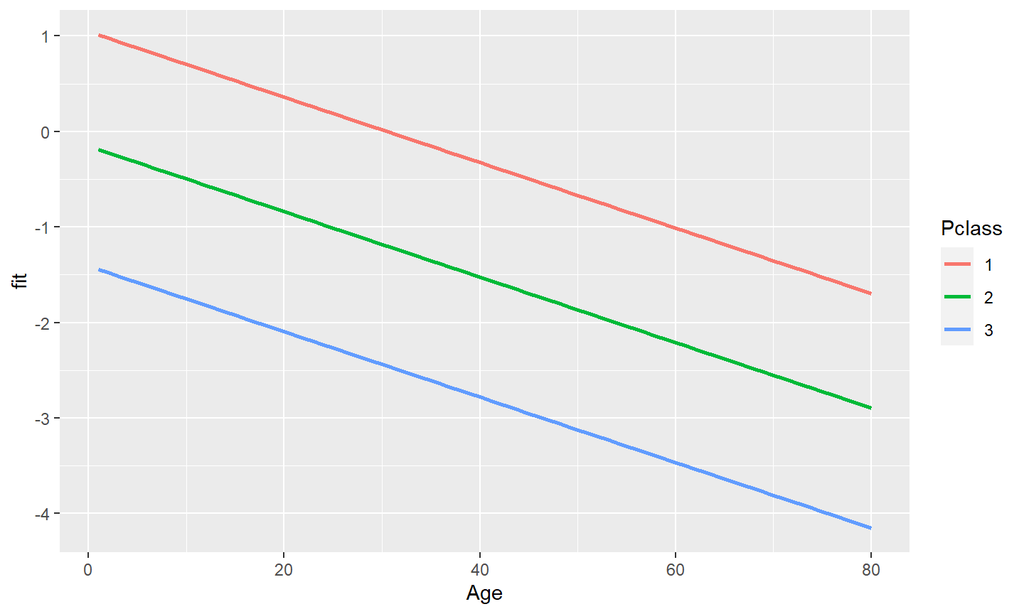

```r
new2 %>%
  ggplot(aes(x = Age, y = fit)) +
  geom_line(aes(colour = Pclass), lwd = 1)
```

## No interaction: probabilities

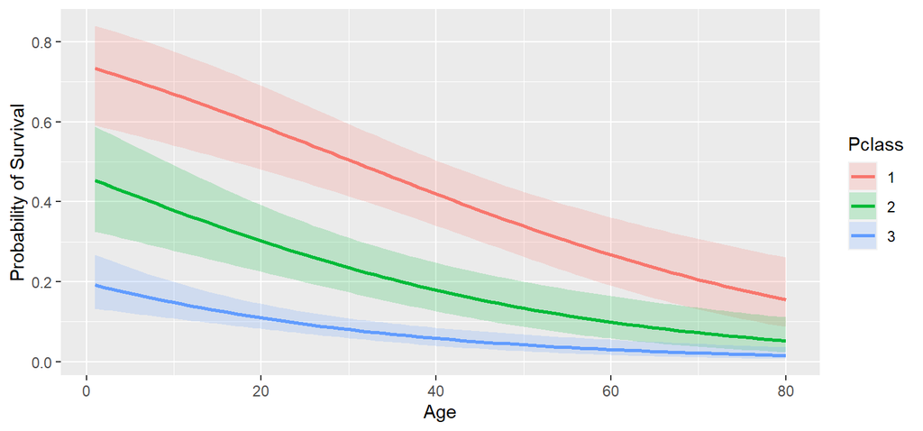

```r
new2 %>%
  ggplot(aes(x = Age, y = prob)) +
  geom_ribbon(aes(ymin = lower, ymax = upper, fill = Pclass), alpha = .2) +
  geom_line(aes(colour = Pclass), lwd = 1) + ylab("Probability of Survival")
```

## Model comparison

```r
anova(fit, fit.interaction, test = "Chisq")
```

```
## Analysis of Deviance Table
##
## Model 1: Survived ~ Age + Sex + Pclass
## Model 2: Survived ~ Age * Sex * Pclass
##   Resid. Df Resid. Dev Df Deviance  Pr(>Chi)
## 1       882     801.59
## 2       875     755.18  7   46.413 7.263e-08 ***
## ---
## Signif. codes:  0 '***' 0.001 '**' 0.01 '*' 0.05 '.' 0.1 ' ' 1
```

The interaction model fits much better to the data.

```r
AIC(fit, fit.interaction)
```

```
##                 df      AIC
## fit              5 811.5940
## fit.interaction 12 779.1805
```

## Prediction

```r
pred <- predict(fit, type = "response")
head(pred)
```

```
##          1          2          3          4          5          6
## 0.10309564 0.91153082 0.57158684 0.91947951 0.06856994 0.08829226
```

```r
pred <- ifelse(pred > 0.5, yes = 1, no = 0)
head(pred)
```

```
## 1 2 3 4 5 6
## 0 1 1 1 0 0
```

## Confusion matrix

```r
CM <- table(pred, titanic$Survived)
CM
```

```
##
## pred   0   1
##    0 463 100
##    1  82 242
```

The accuracy can then be calculated as the percentage of correct predictions, i.e. the sum over the diagonal elements divided by the total number of cases:

```r
correct <- CM %>% diag %>% sum
correct / sum(CM)
```

```
## [1] 0.794814
```

## In a function

```r
confusionMatrix(as.factor(pred), reference = as.factor(titanic$Survived))
```

```
## Confusion Matrix and Statistics
##
##           Reference
## Prediction   0   1
##          0 463 100
##          1  82 242
##
##                Accuracy : 0.7948
##                  95% CI : (0.7667, 0.8209)
##     No Information Rate : 0.6144
##     P-Value [Acc > NIR] : <2e-16
##
##                   Kappa : 0.5627
##
##  Mcnemar's Test P-Value : 0.2076
##
##             Sensitivity : 0.8495
##             Specificity : 0.7076
##          Pos Pred Value : 0.8224
##          Neg Pred Value : 0.7469
##              Prevalence : 0.6144
##          Detection Rate : 0.5220
##    Detection Prevalence : 0.6347
##       Balanced Accuracy : 0.7786
##
##        'Positive' Class : 0
##
```

## Sensitivity / Specificity

```
##                        Survived not.Survived
## Predicted Survived            A            B
## Predicted not.Survived        C            D
```

## Cross validating predictive power

```r
fit <- glm(Survived ~ Age + Sex + Pclass, family = binomial(link="logit"),
           data = titanic)
set.seed(123)
cv <- CVbinary(fit)
```

```
##
## Fold:  3 10 2 6 5 4 9 8 7 1
## Internal estimate of accuracy = 0.795
## Cross-validation estimate of accuracy = 0.793
```

The accuracy after crossvalidation is more or less the same as the accuracy in the data as a whole. This indicates that the fitted model may be useful to new data that comes from the same population; i.e. the model may be generalized to new data.

The `CVbinary() function relies on K-fold crossvalidation. This type of crossvalidation relies on randomly splitting the data into folds (parts). To allow you to replicate these results I fix the random seed.

- In real life there is no need for fixing the random seed if reproducibility is not required.

## Cross validating predictive power

```r
set.seed(123)
CVbinary(fit, nfolds = 5)
```

```
##
## Fold:  3 2 5 4 1
## Internal estimate of accuracy = 0.795
## Cross-validation estimate of accuracy = 0.797
```

```r
CVbinary(fit, nfolds = 2)
```

```
##
## Fold:  1 2
## Internal estimate of accuracy = 0.795
## Cross-validation estimate of accuracy = 0.782
```